# Predicting Bulldozer Auction Sale Prices

Kaggle Competition: https://www.kaggle.com/competitions/bluebook-for-bulldozers/overview

```python
import pandas as pd
import numpy as np
```

```python
pd.__version__
```

```
'2.3.3'
```

```python
# requirements.txt
# - pooch # (download data from the internet)
```

```python
!pip install pooch
```

## Getting the Data - it's not on Kaggle anymore

https://github.com/mrdbourke/zero-to-mastery-ml/blob/master/data/bluebook-for-bulldozers.zip

```python
#.cache/manualdl/datasets
```

```python
# hilariously long data extraction script using 'pooch' library
# courtesy of ChatGPT

from pathlib import Path
from urllib.parse import urlparse
import shutil
import zipfile

import pooch


def fetch_zipped_dataset(
    url: str,
    project_root: str | Path = ".",
    cache_root: str | Path | None = None,
    known_hash: str | None = None,
) -> Path:
    """
    Download a ZIP file into a shared cache, extract it, collapse redundant
    same-named wrapper directories, and copy the dataset files into a single
    top-level folder in the current project.

    Example archive name:
        bluebook-for-bulldozers.zip

    Cache layout:
        ~/.cache/datasets/
            bluebook-for-bulldozers/
                bluebook-for-bulldozers.zip
                bluebook-for-bulldozers/
                    <dataset files>

    Project layout:
        ./bluebook-for-bulldozers/
            <dataset files>

    Parameters
    ----------
    url:
        Direct URL to the ZIP archive.

    project_root:
        Directory in which the project dataset folder should be created.
        Defaults to the current working directory.

    cache_root:
        Shared cache root. Defaults to ~/.cache/datasets.

    known_hash:
        Optional Pooch hash, such as "sha256:<hash>".
        Use None to skip hash validation.

    Returns
    -------
    Path
        Path to the dataset folder in the current project.
    """

    project_root = Path(project_root).expanduser().resolve()

    if cache_root is None:
        cache_root = Path.home() / ".cache" / "datasets"
    else:
        cache_root = Path(cache_root).expanduser().resolve()

    # Get the archive filename from the URL.
    archive_name = Path(urlparse(url).path).name

    if not archive_name.lower().endswith(".zip"):
        raise ValueError(f"URL does not appear to point to a ZIP file: {url}")

    # "bluebook-for-bulldozers.zip" -> "bluebook-for-bulldozers"
    dataset_name = Path(archive_name).stem

    # Cache everything for this dataset inside one named directory.
    dataset_cache_dir = cache_root / dataset_name
    dataset_cache_dir.mkdir(parents=True, exist_ok=True)

    zip_path = Path(
        pooch.retrieve(
            url=url,
            known_hash=known_hash,
            path=dataset_cache_dir,
            fname=archive_name,
        )
    )

    # Extract into a folder with the archive's stem.
    extracted_dir = dataset_cache_dir / dataset_name

    if not extracted_dir.exists():
        extracted_dir.mkdir(parents=True)

        with zipfile.ZipFile(zip_path) as archive:
            archive.extractall(extracted_dir)

    # Some ZIP files contain another same-named folder:
    #
    # extracted_dir/
    #     bluebook-for-bulldozers/
    #         bluebook-for-bulldozers/
    #             files...
    #
    # Walk downward through repeated same-named wrapper directories.
    source_dir = extracted_dir

    while True:
        children = [
            child
            for child in source_dir.iterdir()
            if child.name != "__MACOSX"
        ]

        same_named_child = source_dir / dataset_name

        if (
            len(children) == 1
            and same_named_child.is_dir()
            and children[0] == same_named_child
        ):
            source_dir = same_named_child
        else:
            break

    # Create exactly one top-level project directory.
    project_dataset_dir = project_root / dataset_name
    project_dataset_dir.mkdir(parents=True, exist_ok=True)

    # Copy the contents of the innermost useful directory—not the directory
    # itself—so no redundant nesting is introduced.
    for item in source_dir.iterdir():
        if item.name == "__MACOSX":
            continue

        destination = project_dataset_dir / item.name

        if item.is_dir():
            shutil.copytree(
                item,
                destination,
                dirs_exist_ok=True,
            )
        else:
            shutil.copy2(item, destination)

    return project_dataset_dir


# ---------------------------------------------------------------------
# Download and prepare the Blue Book for Bulldozers dataset
# ---------------------------------------------------------------------

DATA = fetch_zipped_dataset(
    url=(
        "https://github.com/mrdbourke/zero-to-mastery-ml/"
        "raw/master/data/bluebook-for-bulldozers.zip"
    )
)

print(f"Dataset available at:\n{DATA}")
print("\nFiles:")
for path in sorted(DATA.iterdir()):
    print(f"  {path.name}")
```

```
Dataset available at:
/Users/emma/Documents/file_cabinet/people_projects/emma/deeplearning/fastai/fastbook/bluebook-for-bulldozers

Files:
  Data Dictionary.xlsx
  Machine_Appendix.csv
  Test.csv
  Train.7z
  Train.csv
  Train.zip
  TrainAndValid.7z
  TrainAndValid.csv
  TrainAndValid.zip
  Valid.7z
  Valid.csv
  Valid.zip
  ValidSolution.csv
  median_benchmark.csv
  random_forest_benchmark_test.csv
  test_predictions.csv
  to_bulldozers.pkl
  train_tmp.csv
  valid_xs_final.pkl
  xs_final.pkl
```

## What data do we have?

```python
path = Path('./bluebook-for-bulldozers')
```

```python
df_machine_appendix = pd.read_csv(path/'Machine_Appendix.csv')
df_machine_appendix.head()
```

|  | MachineID | ModelID | fiModelDesc | fiBaseModel | fiSecondaryDesc | fiModelSeries | fiModelDescriptor | fiProductClassDesc | ProductGroup | ProductGroupDesc | MfgYear | fiManufacturerID | fiManufacturerDesc | PrimarySizeBasis | PrimaryLower | PrimaryUpper |
| --- | --- | --- | --- | --- | --- | --- | --- | --- | --- | --- | --- | --- | --- | --- | --- | --- |
| 0 | 113 | 1355 | 350L | 350 | NaN | NaN | L | Hydraulic Excavator, Track - 50.0 to 66.0 Metr... | TEX | Track Excavators | 1994.0 | 26 | Caterpillar | Weight - Metric Tons | 50.0 | 66.0 |
| 1 | 434 | 3538 | 416C | 416 | C | NaN | NaN | Backhoe Loader - 14.0 to 15.0 Ft Standard Digg... | BL | Backhoe Loaders | 1997.0 | 26 | Caterpillar | Standard Digging Depth - Ft | 14.0 | 15.0 |
| 2 | 534 | 3538 | 416C | 416 | C | NaN | NaN | Backhoe Loader - 14.0 to 15.0 Ft Standard Digg... | BL | Backhoe Loaders | 1998.0 | 26 | Caterpillar | Standard Digging Depth - Ft | 14.0 | 15.0 |
| 3 | 718 | 3538 | 416C | 416 | C | NaN | NaN | Backhoe Loader - 14.0 to 15.0 Ft Standard Digg... | BL | Backhoe Loaders | 2000.0 | 26 | Caterpillar | Standard Digging Depth - Ft | 14.0 | 15.0 |
| 4 | 1753 | 1580 | D5GLGP | D5 | G | NaN | LGP | Track Type Tractor, Dozer - 85.0 to 105.0 Hors... | TTT | Track Type Tractors | 2006.0 | 26 | Caterpillar | Horsepower | 85.0 | 105.0 |

```python
df_machine_appendix.columns
```

```
Index(['MachineID', 'ModelID', 'fiModelDesc', 'fiBaseModel', 'fiSecondaryDesc',
       'fiModelSeries', 'fiModelDescriptor', 'fiProductClassDesc',
       'ProductGroup', 'ProductGroupDesc', 'MfgYear', 'fiManufacturerID',
       'fiManufacturerDesc', 'PrimarySizeBasis', 'PrimaryLower',
       'PrimaryUpper'],
      dtype='object')
```

```python
df_train = pd.read_csv(path/'Train.csv', low_memory=False)
df_train_and_valid = pd.read_csv(path/'TrainAndValid.csv', low_memory=False)
df_test = pd.read_csv(path/'Test.csv', low_memory=False)
```

```python
df_train # 401,125 rows × 53 columns
```

|  | SalesID | SalePrice | MachineID | ModelID | datasource | auctioneerID | YearMade | MachineHoursCurrentMeter | UsageBand | saledate | ... | Undercarriage_Pad_Width | Stick_Length | Thumb | Pattern_Changer | Grouser_Type | Backhoe_Mounting | Blade_Type | Travel_Controls | Differential_Type | Steering_Controls |
| --- | --- | --- | --- | --- | --- | --- | --- | --- | --- | --- | --- | --- | --- | --- | --- | --- | --- | --- | --- | --- | --- |
| 0 | 1139246 | 66000 | 999089 | 3157 | 121 | 3.0 | 2004 | 68.0 | Low | 11/16/2006 0:00 | ... | NaN | NaN | NaN | NaN | NaN | NaN | NaN | NaN | Standard | Conventional |
| 1 | 1139248 | 57000 | 117657 | 77 | 121 | 3.0 | 1996 | 4640.0 | Low | 3/26/2004 0:00 | ... | NaN | NaN | NaN | NaN | NaN | NaN | NaN | NaN | Standard | Conventional |
| 2 | 1139249 | 10000 | 434808 | 7009 | 121 | 3.0 | 2001 | 2838.0 | High | 2/26/2004 0:00 | ... | NaN | NaN | NaN | NaN | NaN | NaN | NaN | NaN | NaN | NaN |
| 3 | 1139251 | 38500 | 1026470 | 332 | 121 | 3.0 | 2001 | 3486.0 | High | 5/19/2011 0:00 | ... | NaN | NaN | NaN | NaN | NaN | NaN | NaN | NaN | NaN | NaN |
| 4 | 1139253 | 11000 | 1057373 | 17311 | 121 | 3.0 | 2007 | 722.0 | Medium | 7/23/2009 0:00 | ... | NaN | NaN | NaN | NaN | NaN | NaN | NaN | NaN | NaN | NaN |
| ... | ... | ... | ... | ... | ... | ... | ... | ... | ... | ... | ... | ... | ... | ... | ... | ... | ... | ... | ... | ... | ... |
| 401120 | 6333336 | 10500 | 1840702 | 21439 | 149 | 1.0 | 2005 | NaN | NaN | 11/2/2011 0:00 | ... | None or Unspecified | None or Unspecified | None or Unspecified | None or Unspecified | Double | NaN | NaN | NaN | NaN | NaN |
| 401121 | 6333337 | 11000 | 1830472 | 21439 | 149 | 1.0 | 2005 | NaN | NaN | 11/2/2011 0:00 | ... | None or Unspecified | None or Unspecified | None or Unspecified | None or Unspecified | Double | NaN | NaN | NaN | NaN | NaN |
| 401122 | 6333338 | 11500 | 1887659 | 21439 | 149 | 1.0 | 2005 | NaN | NaN | 11/2/2011 0:00 | ... | None or Unspecified | None or Unspecified | None or Unspecified | None or Unspecified | Double | NaN | NaN | NaN | NaN | NaN |
| 401123 | 6333341 | 9000 | 1903570 | 21435 | 149 | 2.0 | 2005 | NaN | NaN | 10/25/2011 0:00 | ... | None or Unspecified | None or Unspecified | None or Unspecified | None or Unspecified | Double | NaN | NaN | NaN | NaN | NaN |
| 401124 | 6333342 | 7750 | 1926965 | 21435 | 149 | 2.0 | 2005 | NaN | NaN | 10/25/2011 0:00 | ... | None or Unspecified | None or Unspecified | None or Unspecified | None or Unspecified | Double | NaN | NaN | NaN | NaN | NaN |

401125 rows × 53 columns

```python
df_train_and_valid # 412,698 rows × 53 columns
```

|  | SalesID | SalePrice | MachineID | ModelID | datasource | auctioneerID | YearMade | MachineHoursCurrentMeter | UsageBand | saledate | ... | Undercarriage_Pad_Width | Stick_Length | Thumb | Pattern_Changer | Grouser_Type | Backhoe_Mounting | Blade_Type | Travel_Controls | Differential_Type | Steering_Controls |
| --- | --- | --- | --- | --- | --- | --- | --- | --- | --- | --- | --- | --- | --- | --- | --- | --- | --- | --- | --- | --- | --- |
| 0 | 1139246 | 66000.0 | 999089 | 3157 | 121 | 3.0 | 2004 | 68.0 | Low | 11/16/2006 0:00 | ... | NaN | NaN | NaN | NaN | NaN | NaN | NaN | NaN | Standard | Conventional |
| 1 | 1139248 | 57000.0 | 117657 | 77 | 121 | 3.0 | 1996 | 4640.0 | Low | 3/26/2004 0:00 | ... | NaN | NaN | NaN | NaN | NaN | NaN | NaN | NaN | Standard | Conventional |
| 2 | 1139249 | 10000.0 | 434808 | 7009 | 121 | 3.0 | 2001 | 2838.0 | High | 2/26/2004 0:00 | ... | NaN | NaN | NaN | NaN | NaN | NaN | NaN | NaN | NaN | NaN |
| 3 | 1139251 | 38500.0 | 1026470 | 332 | 121 | 3.0 | 2001 | 3486.0 | High | 5/19/2011 0:00 | ... | NaN | NaN | NaN | NaN | NaN | NaN | NaN | NaN | NaN | NaN |
| 4 | 1139253 | 11000.0 | 1057373 | 17311 | 121 | 3.0 | 2007 | 722.0 | Medium | 7/23/2009 0:00 | ... | NaN | NaN | NaN | NaN | NaN | NaN | NaN | NaN | NaN | NaN |
| ... | ... | ... | ... | ... | ... | ... | ... | ... | ... | ... | ... | ... | ... | ... | ... | ... | ... | ... | ... | ... | ... |
| 412693 | 6333344 | 10000.0 | 1919201 | 21435 | 149 | 2.0 | 2005 | NaN | NaN | 3/7/2012 0:00 | ... | None or Unspecified | None or Unspecified | None or Unspecified | None or Unspecified | Double | NaN | NaN | NaN | NaN | NaN |
| 412694 | 6333345 | 10500.0 | 1882122 | 21436 | 149 | 2.0 | 2005 | NaN | NaN | 1/28/2012 0:00 | ... | None or Unspecified | None or Unspecified | None or Unspecified | None or Unspecified | Double | NaN | NaN | NaN | NaN | NaN |
| 412695 | 6333347 | 12500.0 | 1944213 | 21435 | 149 | 2.0 | 2005 | NaN | NaN | 1/28/2012 0:00 | ... | None or Unspecified | None or Unspecified | None or Unspecified | None or Unspecified | Double | NaN | NaN | NaN | NaN | NaN |
| 412696 | 6333348 | 10000.0 | 1794518 | 21435 | 149 | 2.0 | 2006 | NaN | NaN | 3/7/2012 0:00 | ... | None or Unspecified | None or Unspecified | None or Unspecified | None or Unspecified | Double | NaN | NaN | NaN | NaN | NaN |
| 412697 | 6333349 | 13000.0 | 1944743 | 21436 | 149 | 2.0 | 2006 | NaN | NaN | 1/28/2012 0:00 | ... | None or Unspecified | None or Unspecified | None or Unspecified | None or Unspecified | Double | NaN | NaN | NaN | NaN | NaN |

412698 rows × 53 columns

```python
# df_train.columns # df_test is just missing SalePrice
# Index(['SalesID', 'SalePrice', 'MachineID', 'ModelID', 'datasource',
#        'auctioneerID', 'YearMade', 'MachineHoursCurrentMeter', 'UsageBand',
#        'saledate', 'fiModelDesc', 'fiBaseModel', 'fiSecondaryDesc',
#        'fiModelSeries', 'fiModelDescriptor', 'ProductSize',
#        'fiProductClassDesc', 'state', 'ProductGroup', 'ProductGroupDesc',
#        'Drive_System', 'Enclosure', 'Forks', 'Pad_Type', 'Ride_Control',
#        'Stick', 'Transmission', 'Turbocharged', 'Blade_Extension',
#        'Blade_Width', 'Enclosure_Type', 'Engine_Horsepower', 'Hydraulics',
#        'Pushblock', 'Ripper', 'Scarifier', 'Tip_Control', 'Tire_Size',
#        'Coupler', 'Coupler_System', 'Grouser_Tracks', 'Hydraulics_Flow',
#        'Track_Type', 'Undercarriage_Pad_Width', 'Stick_Length', 'Thumb',
#        'Pattern_Changer', 'Grouser_Type', 'Backhoe_Mounting', 'Blade_Type',
#        'Travel_Controls', 'Differential_Type', 'Steering_Controls'],
#       dtype='object')
```

```python
df_test # 12457 rows × 52 columns
```

|  | SalesID | MachineID | ModelID | datasource | auctioneerID | YearMade | MachineHoursCurrentMeter | UsageBand | saledate | fiModelDesc | ... | Undercarriage_Pad_Width | Stick_Length | Thumb | Pattern_Changer | Grouser_Type | Backhoe_Mounting | Blade_Type | Travel_Controls | Differential_Type | Steering_Controls |
| --- | --- | --- | --- | --- | --- | --- | --- | --- | --- | --- | --- | --- | --- | --- | --- | --- | --- | --- | --- | --- | --- |
| 0 | 1227829 | 1006309 | 3168 | 121 | 3 | 1999 | 3688.0 | Low | 5/3/2012 0:00 | 580G | ... | NaN | NaN | NaN | NaN | NaN | NaN | NaN | NaN | NaN | NaN |
| 1 | 1227844 | 1022817 | 7271 | 121 | 3 | 1000 | 28555.0 | High | 5/10/2012 0:00 | 936 | ... | NaN | NaN | NaN | NaN | NaN | NaN | NaN | NaN | Standard | Conventional |
| 2 | 1227847 | 1031560 | 22805 | 121 | 3 | 2004 | 6038.0 | Medium | 5/10/2012 0:00 | EC210BLC | ... | None or Unspecified | 9' 6" | Manual | None or Unspecified | Double | NaN | NaN | NaN | NaN | NaN |
| 3 | 1227848 | 56204 | 1269 | 121 | 3 | 2006 | 8940.0 | High | 5/10/2012 0:00 | 330CL | ... | None or Unspecified | None or Unspecified | Manual | Yes | Triple | NaN | NaN | NaN | NaN | NaN |
| 4 | 1227863 | 1053887 | 22312 | 121 | 3 | 2005 | 2286.0 | Low | 5/10/2012 0:00 | 650K | ... | NaN | NaN | NaN | NaN | NaN | None or Unspecified | PAT | None or Unspecified | NaN | NaN |
| ... | ... | ... | ... | ... | ... | ... | ... | ... | ... | ... | ... | ... | ... | ... | ... | ... | ... | ... | ... | ... | ... |
| 12452 | 6643171 | 2558317 | 21450 | 149 | 2 | 2008 | NaN | NaN | 10/24/2012 0:00 | 80NX3 | ... | None or Unspecified | None or Unspecified | None or Unspecified | None or Unspecified | Double | NaN | NaN | NaN | NaN | NaN |
| 12453 | 6643173 | 2558332 | 21434 | 149 | 2 | 2005 | NaN | NaN | 10/24/2012 0:00 | 28N | ... | None or Unspecified | None or Unspecified | None or Unspecified | None or Unspecified | Double | NaN | NaN | NaN | NaN | NaN |
| 12454 | 6643184 | 2558342 | 21437 | 149 | 2 | 1000 | NaN | NaN | 10/24/2012 0:00 | 35N | ... | None or Unspecified | None or Unspecified | None or Unspecified | None or Unspecified | Double | NaN | NaN | NaN | NaN | NaN |
| 12455 | 6643186 | 2558343 | 21437 | 149 | 2 | 2006 | NaN | NaN | 10/24/2012 0:00 | 35N | ... | None or Unspecified | None or Unspecified | None or Unspecified | None or Unspecified | Double | NaN | NaN | NaN | NaN | NaN |
| 12456 | 6643196 | 2558346 | 21446 | 149 | 2 | 2008 | NaN | NaN | 9/19/2012 0:00 | 55N2 | ... | None or Unspecified | None or Unspecified | None or Unspecified | None or Unspecified | Double | NaN | NaN | NaN | NaN | NaN |

12457 rows × 52 columns

```python
df_train # 53 columns, 401125 rows
```

|  | SalesID | SalePrice | MachineID | ModelID | datasource | auctioneerID | YearMade | MachineHoursCurrentMeter | UsageBand | saledate | ... | Undercarriage_Pad_Width | Stick_Length | Thumb | Pattern_Changer | Grouser_Type | Backhoe_Mounting | Blade_Type | Travel_Controls | Differential_Type | Steering_Controls |
| --- | --- | --- | --- | --- | --- | --- | --- | --- | --- | --- | --- | --- | --- | --- | --- | --- | --- | --- | --- | --- | --- |
| 0 | 1139246 | 66000 | 999089 | 3157 | 121 | 3.0 | 2004 | 68.0 | Low | 11/16/2006 0:00 | ... | NaN | NaN | NaN | NaN | NaN | NaN | NaN | NaN | Standard | Conventional |
| 1 | 1139248 | 57000 | 117657 | 77 | 121 | 3.0 | 1996 | 4640.0 | Low | 3/26/2004 0:00 | ... | NaN | NaN | NaN | NaN | NaN | NaN | NaN | NaN | Standard | Conventional |
| 2 | 1139249 | 10000 | 434808 | 7009 | 121 | 3.0 | 2001 | 2838.0 | High | 2/26/2004 0:00 | ... | NaN | NaN | NaN | NaN | NaN | NaN | NaN | NaN | NaN | NaN |
| 3 | 1139251 | 38500 | 1026470 | 332 | 121 | 3.0 | 2001 | 3486.0 | High | 5/19/2011 0:00 | ... | NaN | NaN | NaN | NaN | NaN | NaN | NaN | NaN | NaN | NaN |
| 4 | 1139253 | 11000 | 1057373 | 17311 | 121 | 3.0 | 2007 | 722.0 | Medium | 7/23/2009 0:00 | ... | NaN | NaN | NaN | NaN | NaN | NaN | NaN | NaN | NaN | NaN |
| ... | ... | ... | ... | ... | ... | ... | ... | ... | ... | ... | ... | ... | ... | ... | ... | ... | ... | ... | ... | ... | ... |
| 401120 | 6333336 | 10500 | 1840702 | 21439 | 149 | 1.0 | 2005 | NaN | NaN | 11/2/2011 0:00 | ... | None or Unspecified | None or Unspecified | None or Unspecified | None or Unspecified | Double | NaN | NaN | NaN | NaN | NaN |
| 401121 | 6333337 | 11000 | 1830472 | 21439 | 149 | 1.0 | 2005 | NaN | NaN | 11/2/2011 0:00 | ... | None or Unspecified | None or Unspecified | None or Unspecified | None or Unspecified | Double | NaN | NaN | NaN | NaN | NaN |
| 401122 | 6333338 | 11500 | 1887659 | 21439 | 149 | 1.0 | 2005 | NaN | NaN | 11/2/2011 0:00 | ... | None or Unspecified | None or Unspecified | None or Unspecified | None or Unspecified | Double | NaN | NaN | NaN | NaN | NaN |
| 401123 | 6333341 | 9000 | 1903570 | 21435 | 149 | 2.0 | 2005 | NaN | NaN | 10/25/2011 0:00 | ... | None or Unspecified | None or Unspecified | None or Unspecified | None or Unspecified | Double | NaN | NaN | NaN | NaN | NaN |
| 401124 | 6333342 | 7750 | 1926965 | 21435 | 149 | 2.0 | 2005 | NaN | NaN | 10/25/2011 0:00 | ... | None or Unspecified | None or Unspecified | None or Unspecified | None or Unspecified | Double | NaN | NaN | NaN | NaN | NaN |

401125 rows × 53 columns

```python
df_train_and_valid.columns # 53 columns
```

```
Index(['SalesID', 'SalePrice', 'MachineID', 'ModelID', 'datasource',
       'auctioneerID', 'YearMade', 'MachineHoursCurrentMeter', 'UsageBand',
       'saledate', 'fiModelDesc', 'fiBaseModel', 'fiSecondaryDesc',
       'fiModelSeries', 'fiModelDescriptor', 'ProductSize',
       'fiProductClassDesc', 'state', 'ProductGroup', 'ProductGroupDesc',
       'Drive_System', 'Enclosure', 'Forks', 'Pad_Type', 'Ride_Control',
       'Stick', 'Transmission', 'Turbocharged', 'Blade_Extension',
       'Blade_Width', 'Enclosure_Type', 'Engine_Horsepower', 'Hydraulics',
       'Pushblock', 'Ripper', 'Scarifier', 'Tip_Control', 'Tire_Size',
       'Coupler', 'Coupler_System', 'Grouser_Tracks', 'Hydraulics_Flow',
       'Track_Type', 'Undercarriage_Pad_Width', 'Stick_Length', 'Thumb',
       'Pattern_Changer', 'Grouser_Type', 'Backhoe_Mounting', 'Blade_Type',
       'Travel_Controls', 'Differential_Type', 'Steering_Controls'],
      dtype='object')
```

```python
df_test.columns # 52 columns
```

```
Index(['SalesID', 'MachineID', 'ModelID', 'datasource', 'auctioneerID',
       'YearMade', 'MachineHoursCurrentMeter', 'UsageBand', 'saledate',
       'fiModelDesc', 'fiBaseModel', 'fiSecondaryDesc', 'fiModelSeries',
       'fiModelDescriptor', 'ProductSize', 'fiProductClassDesc', 'state',
       'ProductGroup', 'ProductGroupDesc', 'Drive_System', 'Enclosure',
       'Forks', 'Pad_Type', 'Ride_Control', 'Stick', 'Transmission',
       'Turbocharged', 'Blade_Extension', 'Blade_Width', 'Enclosure_Type',
       'Engine_Horsepower', 'Hydraulics', 'Pushblock', 'Ripper', 'Scarifier',
       'Tip_Control', 'Tire_Size', 'Coupler', 'Coupler_System',
       'Grouser_Tracks', 'Hydraulics_Flow', 'Track_Type',
       'Undercarriage_Pad_Width', 'Stick_Length', 'Thumb', 'Pattern_Changer',
       'Grouser_Type', 'Backhoe_Mounting', 'Blade_Type', 'Travel_Controls',
       'Differential_Type', 'Steering_Controls'],
      dtype='object')
```

```python
df_train.describe()
```

|  | SalesID | SalePrice | MachineID | ModelID | datasource | auctioneerID | YearMade | MachineHoursCurrentMeter |
| --- | --- | --- | --- | --- | --- | --- | --- | --- |
| count | 4.011250e+05 | 401125.000000 | 4.011250e+05 | 401125.000000 | 401125.000000 | 380989.000000 | 401125.000000 | 1.427650e+05 |
| mean | 1.919713e+06 | 31099.712848 | 1.217903e+06 | 6889.702980 | 134.665810 | 6.556040 | 1899.156901 | 3.457955e+03 |
| std | 9.090215e+05 | 23036.898502 | 4.409920e+05 | 6221.777842 | 8.962237 | 16.976779 | 291.797469 | 2.759026e+04 |
| min | 1.139246e+06 | 4750.000000 | 0.000000e+00 | 28.000000 | 121.000000 | 0.000000 | 1000.000000 | 0.000000e+00 |
| 25% | 1.418371e+06 | 14500.000000 | 1.088697e+06 | 3259.000000 | 132.000000 | 1.000000 | 1985.000000 | 0.000000e+00 |
| 50% | 1.639422e+06 | 24000.000000 | 1.279490e+06 | 4604.000000 | 132.000000 | 2.000000 | 1995.000000 | 0.000000e+00 |
| 75% | 2.242707e+06 | 40000.000000 | 1.468067e+06 | 8724.000000 | 136.000000 | 4.000000 | 2000.000000 | 3.025000e+03 |
| max | 6.333342e+06 | 142000.000000 | 2.486330e+06 | 37198.000000 | 172.000000 | 99.000000 | 2013.000000 | 2.483300e+06 |

```python
len(df_train_and_valid)
```

```
412698
```

```python
df_train_and_valid.SalePrice.info()
```

```
<class 'pandas.core.series.Series'>
RangeIndex: 412698 entries, 0 to 412697
Series name: SalePrice
Non-Null Count   Dtype
--------------   -----
412698 non-null  float64
dtypes: float64(1)
memory usage: 3.1 MB
```

## Let's clean up the data

### Handle Ordinal Columns

```python
df_train_and_valid.ProductSize.unique()
```

```
array([nan, 'Medium', 'Small', 'Large / Medium', 'Mini', 'Large',
       'Compact'], dtype=object)
```

```python
sizes = 'Large','Large / Medium','Medium','Small','Mini','Compact'
```

```python
# set ProductSize to "category" type and give ordered categories
df_train_and_valid['ProductSize'] = df_train_and_valid['ProductSize'].astype('category')
df_train_and_valid['ProductSize'] = df_train_and_valid['ProductSize'].cat.set_categories(sizes, ordered=True)
```

### Make SalePrice into log(SalePrice) b/c the metric will be on RMSE of the log(SalePrice)

```python
dep_var = 'SalePrice'
df_train_and_valid[dep_var] = np.log(df_train_and_valid[dep_var])
```

### Enriching the Dates for the train_and_valid and test sets

First, making sure the saledate column is a `datetime` type rather than a plain `object`.

```python
df_train_and_valid['saledate'].unique()
```

```
array(['11/16/2006 0:00', '3/26/2004 0:00', '2/26/2004 0:00', ...,
       '3/10/2012 0:00', '3/9/2012 0:00', '4/14/2012 0:00'],
      shape=(4013,), dtype=object)
```

```python
df_train_and_valid['saledate'] = pd.to_datetime(df_train_and_valid['saledate'])
```

```python
df_train_and_valid['saledate']
```

```
0        2006-11-16
1        2004-03-26
2        2004-02-26
3        2011-05-19
4        2009-07-23
            ...
412693   2012-03-07
412694   2012-01-28
412695   2012-01-28
412696   2012-03-07
412697   2012-01-28
Name: saledate, Length: 412698, dtype: datetime64[ns]
```

Then, add the extra fields -- note: this removes the original 'saledate' column. Docs here: https://docs.fast.ai/tabular.core.html

```python
# this is the first invocation of the fastai library for this notebook
# need it for the "add_datepart" thing that adds extra date metadata columns
import fastai
from fastai.tabular.core import add_datepart
```

```python
fastai.__version__ #'2.8.7'
```

```
'2.8.7'
```

```python
df_train_and_valid = add_datepart(df_train_and_valid, 'saledate')
```

```python
## for the df_test, too
df_test['saledate'] = pd.to_datetime(df_test['saledate'])
df_test = add_datepart(df_test, 'saledate')
```

#### df_train_and_valid now has 13 new fields (and one less: 'saledate')

- 'saleYear',
- 'saleMonth',
- 'saleWeek',
- 'saleDay',
- 'saleDayofweek',
- 'saleDayofyear',
- 'saleIs_month_end',
- 'saleIs_month_start',
- 'saleIs_quarter_end',
- 'saleIs_quarter_start',
- 'saleIs_year_end',
- 'saleIs_year_start',
- 'saleElapsed': ": The Unix timestamp, representing the total number of seconds elapsed since January 1, 1970."

### Use fastai's TabularPandas and TabularProc

`TabularProc` has helper functions you can apply to `TabularPandas` objects -- e.g. for:

- `FillMissing`: replaces missing values with the median of the column, and creates a new Boolean column that is set to True for any row where the value was missing
- `Categorify`: replaces a column with a numeric categorical column

#### First, assign rows to train and validation sets, paying attention to the fact that this is a timeseries

```python
cond = (df_train_and_valid.saleYear<2011) | (df_train_and_valid.saleMonth<10)
train_idx = np.where( cond)[0]
valid_idx = np.where(~cond)[0]

splits = (list(train_idx),list(valid_idx))
```

#### Designate columns as 'categorical' or 'continuous'

```python
from fastai.tabular.core import cont_cat_split
cont,cat = cont_cat_split(df_train_and_valid, 1, dep_var=dep_var)
```

#### Set up the TabularPandas object and the Procs we're going to use

```python
from fastai.tabular.all import TabularPandas, Categorify, FillMissing
```

```python
procs = [Categorify, FillMissing]
```

```python
to = TabularPandas(df_train_and_valid, procs, cat, cont, y_names=dep_var, splits=splits)
```

#### Check what the procs have done

confusingly, the TabularPandas object has a `.show()` function that gives the human readable values in the columns. To see what values are actually stored in the `df` you have to call `.items()`

```python
len(to.train),len(to.valid)
```

```
(404710, 7988)
```

```python
to.show(3)
```

|  | UsageBand | fiModelDesc | fiBaseModel | fiSecondaryDesc | fiModelSeries | fiModelDescriptor | ProductSize | fiProductClassDesc | state | ProductGroup | ProductGroupDesc | Drive_System | Enclosure | Forks | Pad_Type | Ride_Control | Stick | Transmission | Turbocharged | Blade_Extension | Blade_Width | Enclosure_Type | Engine_Horsepower | Hydraulics | Pushblock | Ripper | Scarifier | Tip_Control | Tire_Size | … |
| --- | --- | --- | --- | --- | --- | --- | --- | --- | --- | --- | --- | --- | --- | --- | --- | --- | --- | --- | --- | --- | --- | --- | --- | --- | --- | --- | --- | --- | --- | --- |
| 0 | Low | 521D | 521 | D | #na# | #na# | #na# | Wheel Loader - 110.0 to 120.0 Horsepower | Alabama | WL | Wheel Loader | #na# | EROPS w AC | None or Unspecified | #na# | None or Unspecified | #na# | #na# | #na# | #na# | #na# | #na# | #na# | 2 Valve | #na# | #na# | #na# | #na# | None or Unspecified | … |
| 1 | Low | 950FII | 950 | F | II | #na# | Medium | Wheel Loader - 150.0 to 175.0 Horsepower | North Carolina | WL | Wheel Loader | #na# | EROPS w AC | None or Unspecified | #na# | None or Unspecified | #na# | #na# | #na# | #na# | #na# | #na# | #na# | 2 Valve | #na# | #na# | #na# | #na# | 23.5 | … |
| 2 | High | 226 | 226 | #na# | #na# | #na# | #na# | Skid Steer Loader - 1351.0 to 1601.0 Lb Operating Capacity | New York | SSL | Skid Steer Loaders | #na# | OROPS | None or Unspecified | #na# | #na# | #na# | #na# | #na# | #na# | #na# | #na# | #na# | Auxiliary | #na# | #na# | #na# | #na# | #na# | … |

```python
to1 = TabularPandas(df_train_and_valid, procs, ['state', 'ProductGroup', 'Drive_System', 'Enclosure'], [], y_names=dep_var, splits=splits)
to1.show(3)
```

|  | state | ProductGroup | Drive_System | Enclosure | SalePrice |
| --- | --- | --- | --- | --- | --- |
| 0 | Alabama | WL | #na# | EROPS w AC | 11.097410 |
| 1 | North Carolina | WL | #na# | EROPS w AC | 10.950807 |
| 2 | New York | SSL | #na# | OROPS | 9.210340 |

```python
to.items.head(3)
```

|  | SalesID | SalePrice | MachineID | ModelID | datasource | auctioneerID | YearMade | MachineHoursCurrentMeter | UsageBand | fiModelDesc | ... | saleDayofyear | saleIs_month_end | saleIs_month_start | saleIs_quarter_end | saleIs_quarter_start | saleIs_year_end | saleIs_year_start | saleElapsed | auctioneerID_na | MachineHoursCurrentMeter_na |
| --- | --- | --- | --- | --- | --- | --- | --- | --- | --- | --- | --- | --- | --- | --- | --- | --- | --- | --- | --- | --- | --- |
| 0 | 1139246 | 11.097410 | 999089 | 3157 | 121 | 3.0 | 2004 | 68.0 | 2 | 963 | ... | 320 | 1 | 1 | 1 | 1 | 1 | 1 | 1.163635e+09 | 1 | 1 |
| 1 | 1139248 | 10.950807 | 117657 | 77 | 121 | 3.0 | 1996 | 4640.0 | 2 | 1745 | ... | 86 | 1 | 1 | 1 | 1 | 1 | 1 | 1.080259e+09 | 1 | 1 |
| 2 | 1139249 | 9.210340 | 434808 | 7009 | 121 | 3.0 | 2001 | 2838.0 | 1 | 336 | ... | 57 | 1 | 1 | 1 | 1 | 1 | 1 | 1.077754e+09 | 1 | 1 |

3 rows × 67 columns

```python
to1.items[['state', 'ProductGroup', 'Drive_System', 'Enclosure']].head(3)
```

|  | state | ProductGroup | Drive_System | Enclosure |
| --- | --- | --- | --- | --- |
| 0 | 1 | 6 | 0 | 3 |
| 1 | 33 | 6 | 0 | 3 |
| 2 | 32 | 3 | 0 | 6 |

```python
to.items.columns
```

```
Index(['SalesID', 'SalePrice', 'MachineID', 'ModelID', 'datasource',
       'auctioneerID', 'YearMade', 'MachineHoursCurrentMeter', 'UsageBand',
       'fiModelDesc', 'fiBaseModel', 'fiSecondaryDesc', 'fiModelSeries',
       'fiModelDescriptor', 'ProductSize', 'fiProductClassDesc', 'state',
       'ProductGroup', 'ProductGroupDesc', 'Drive_System', 'Enclosure',
       'Forks', 'Pad_Type', 'Ride_Control', 'Stick', 'Transmission',
       'Turbocharged', 'Blade_Extension', 'Blade_Width', 'Enclosure_Type',
       'Engine_Horsepower', 'Hydraulics', 'Pushblock', 'Ripper', 'Scarifier',
       'Tip_Control', 'Tire_Size', 'Coupler', 'Coupler_System',
       'Grouser_Tracks', 'Hydraulics_Flow', 'Track_Type',
       'Undercarriage_Pad_Width', 'Stick_Length', 'Thumb', 'Pattern_Changer',
       'Grouser_Type', 'Backhoe_Mounting', 'Blade_Type', 'Travel_Controls',
       'Differential_Type', 'Steering_Controls', 'saleYear', 'saleMonth',
       'saleWeek', 'saleDay', 'saleDayofweek', 'saleDayofyear',
       'saleIs_month_end', 'saleIs_month_start', 'saleIs_quarter_end',
       'saleIs_quarter_start', 'saleIs_year_end', 'saleIs_year_start',
       'saleElapsed', 'auctioneerID_na', 'MachineHoursCurrentMeter_na'],
      dtype='object')
```

```python
to.classes['ProductSize']
```

```
['#na#', 'Large', 'Large / Medium', 'Medium', 'Small', 'Mini', 'Compact']
```

### Because this processing took time, suggested to save a pickle

```python
from fastai.tabular.core import save_pickle, load_pickle
save_pickle(path/'to_bulldozers.pkl',to)
```

### We can read the pickle back, too

```python
# ok so this is the safe way?
#import pickle
#with open(path/'to_bulldozers.pkl', "rb") as f:
#    to = pickle.load(f)

# this is me mimicking the save_pickle import from the fastai.tabular.core library
to = load_pickle(path/'to_bulldozers.pkl')
# this is what they suggested we would use, but doesn't seem to work after I updated
#to = (path/'to_bulldozers.pkl').load()
# from scikit-learn 1.8 to 1.9 (?)

to.show()
```

|  | UsageBand | fiModelDesc | fiBaseModel | fiSecondaryDesc | fiModelSeries | fiModelDescriptor | ProductSize | fiProductClassDesc | state | ProductGroup | ProductGroupDesc | Drive_System | Enclosure | Forks | Pad_Type | Ride_Control | Stick | Transmission | Turbocharged | Blade_Extension | Blade_Width | Enclosure_Type | Engine_Horsepower | Hydraulics | Pushblock | Ripper | Scarifier | Tip_Control | Tire_Size | … |
| --- | --- | --- | --- | --- | --- | --- | --- | --- | --- | --- | --- | --- | --- | --- | --- | --- | --- | --- | --- | --- | --- | --- | --- | --- | --- | --- | --- | --- | --- | --- |
| 0 | Low | 521D | 521 | D | #na# | #na# | #na# | Wheel Loader - 110.0 to 120.0 Horsepower | Alabama | WL | Wheel Loader | #na# | EROPS w AC | None or Unspecified | #na# | None or Unspecified | #na# | #na# | #na# | #na# | #na# | #na# | #na# | 2 Valve | #na# | #na# | #na# | #na# | None or Unspecified | … |
| 1 | Low | 950FII | 950 | F | II | #na# | Medium | Wheel Loader - 150.0 to 175.0 Horsepower | North Carolina | WL | Wheel Loader | #na# | EROPS w AC | None or Unspecified | #na# | None or Unspecified | #na# | #na# | #na# | #na# | #na# | #na# | #na# | 2 Valve | #na# | #na# | #na# | #na# | 23.5 | … |
| 2 | High | 226 | 226 | #na# | #na# | #na# | #na# | Skid Steer Loader - 1351.0 to 1601.0 Lb Operating Capacity | New York | SSL | Skid Steer Loaders | #na# | OROPS | None or Unspecified | #na# | #na# | #na# | #na# | #na# | #na# | #na# | #na# | #na# | Auxiliary | #na# | #na# | #na# | #na# | #na# | … |
| 3 | High | PC120-6E | PC120 | #na# | -6E | #na# | Small | Hydraulic Excavator, Track - 12.0 to 14.0 Metric Tons | Texas | TEX | Track Excavators | #na# | EROPS w AC | #na# | #na# | #na# | #na# | #na# | #na# | #na# | #na# | #na# | #na# | 2 Valve | #na# | #na# | #na# | #na# | #na# | … |
| 4 | Medium | S175 | S175 | #na# | #na# | #na# | #na# | Skid Steer Loader - 1601.0 to 1751.0 Lb Operating Capacity | New York | SSL | Skid Steer Loaders | #na# | EROPS | None or Unspecified | #na# | #na# | #na# | #na# | #na# | #na# | #na# | #na# | #na# | Auxiliary | #na# | #na# | #na# | #na# | #na# | … |
| 5 | Low | 310G | 310 | G | #na# | #na# | #na# | Backhoe Loader - 14.0 to 15.0 Ft Standard Digging Depth | Arizona | BL | Backhoe Loaders | Four Wheel Drive | OROPS | None or Unspecified | None or Unspecified | No | Extended | Powershuttle | None or Unspecified | #na# | #na# | #na# | #na# | #na# | #na# | #na# | #na# | #na# | #na# | … |
| 6 | High | 790ELC | 790 | E | #na# | LC | Large / Medium | Hydraulic Excavator, Track - 21.0 to 24.0 Metric Tons | Florida | TEX | Track Excavators | #na# | EROPS | #na# | #na# | #na# | #na# | #na# | #na# | #na# | #na# | #na# | #na# | Standard | #na# | #na# | #na# | #na# | #na# | … |
| 7 | High | 416D | 416 | D | #na# | #na# | #na# | Backhoe Loader - 14.0 to 15.0 Ft Standard Digging Depth | Illinois | BL | Backhoe Loaders | Four Wheel Drive | OROPS | None or Unspecified | Reversible | No | Standard | Standard | Yes | #na# | #na# | #na# | #na# | #na# | #na# | #na# | #na# | #na# | #na# | … |
| 8 | Low | 430HAG | 430 | HAG | #na# | #na# | Mini | Hydraulic Excavator, Track - 3.0 to 4.0 Metric Tons | Texas | TEX | Track Excavators | #na# | EROPS | #na# | #na# | #na# | #na# | #na# | #na# | #na# | #na# | #na# | #na# | Auxiliary | #na# | #na# | #na# | #na# | #na# | … |
| 9 | Medium | 988B | 988 | B | #na# | #na# | Large | Wheel Loader - 350.0 to 500.0 Horsepower | Florida | WL | Wheel Loader | #na# | EROPS w AC | None or Unspecified | #na# | None or Unspecified | #na# | #na# | #na# | #na# | #na# | #na# | #na# | 2 Valve | #na# | #na# | #na# | #na# | None or Unspecified | … |

## Creating the Decision Tree

According to the authors, "The basic steps to train a decision tree can be written down very easily":

- Loop through each column of the dataset in turn.
- For each column, loop through each possible level of that column in turn.
- Try splitting the data into two groups, based on whether they are greater than or less than that value (or if it is a categorical variable, based on whether they are equal to or not equal to that level of that categorical variable).
- Find the average sale price for each of those two groups, and see how close that is to the actual sale price of each of the items of equipment in that group. That is, treat this as a very simple "model" where our predictions are simply the average sale price of the item's group.
- After looping through all of the columns and all the possible levels for each, pick the split point that gave the best predictions using that simple model.
- We now have two different groups for our data, based on this selected split. Treat each of these as separate datasets, and find the best split for each by going back to step 1 for each group.
- Continue this process recursively, until you have reached some stopping criterion for each group—for instance, stop splitting a group further when it has only 20 items in it.

```python
import pickle
with open(path/'to_bulldozers.pkl', "rb") as f:
    to = pickle.load(f)
```

### Set up our independent and dependent variables for the train & validation sets

```python
xs,y = to.train.xs,to.train.y
valid_xs,valid_y = to.valid.xs,to.valid.y
```

### 1. Let's make the tree!

```python
from sklearn.tree import DecisionTreeRegressor
m = DecisionTreeRegressor(max_leaf_nodes=4)
m.fit(xs, y); # btw the semicolon keeps an interesting visualization of the tree from coming out
```

```python
import sklearn
print(sklearn.__version__)
```

```
1.9.0
```

#### Draw the Tree

this uses a helper function provided in utils.py in fastbook; i'm adding it here

```python
from sklearn.tree import export_graphviz
import graphviz, re

def draw_tree(t, df, size=10, ratio=0.6, precision=0, **kwargs):
    s=export_graphviz(t, out_file=None, feature_names=df.columns, filled=True, rounded=True,
                      special_characters=True, rotate=False, precision=precision, **kwargs)
    return graphviz.Source(re.sub('Tree {', f'Tree {{ size={size}; ratio={ratio}', s))
```

```python
draw_tree(m, xs, size=10, leaves_parallel=True, precision=2)
```

[figure not shown]

We can also draw the tree using another library: Terence Parr's "powerful [dtreeviz](https://explained.ai/decision-tree-viz/) library"

```python
import dtreeviz
print(dtreeviz.__version__)
```

```
2.3.2
```

```python
import numpy as np
import dtreeviz

samp_idx = np.random.permutation(len(y))[:500]

viz_model = dtreeviz.model(
    m,
    X_train=xs.iloc[samp_idx],
    y_train=y.iloc[samp_idx],
    feature_names=[str(c) for c in xs.columns],
    target_name=dep_var,
)

viz_model.view(
    fontname="DejaVu Sans",
    scale=1.6,
    label_fontsize=10,
    orientation="LR",
)
```

[figure not shown]

#### The YearMade shows that there are years all the way down at 1000... let's just fix those values

```python
xs.loc[xs['YearMade']<1900, 'YearMade'] = 1950
valid_xs.loc[valid_xs['YearMade']<1900, 'YearMade'] = 1950
```

### 2. And rebuild/refit the tree

```python
m = DecisionTreeRegressor(max_leaf_nodes=4).fit(xs, y)
```

#### And remake the dtreeviz

```python
samp_idx = np.random.permutation(len(y))[:500]

viz_model = dtreeviz.model(
    m,
    X_train=xs.iloc[samp_idx],
    y_train=y.iloc[samp_idx],
    feature_names=[str(c) for c in xs.columns],
    target_name=dep_var,
)

viz_model.view(
    fontname="DejaVu Sans",
    scale=1.6,
    label_fontsize=10,
    orientation="LR",
)
```

[figure not shown]

### 3. Let's make a bigger tree!

```python
m = DecisionTreeRegressor() # we won't pass in any criteria for the leaves
m.fit(xs, y);
```

#### And let's write a function for our metric, the root mean squared (log) error (recall we already did log(SalePrice))

```python
import math
def r_mse(pred,y): return round(math.sqrt(((pred-y)**2).mean()), 6)
def m_rmse(m, xs, y): return r_mse(m.predict(xs), y)
```

#### For the full tree... we have a root mean square error of 0 for the training data!

```python
m_rmse(m, xs, y)
```

```
0.0
```

#### What's the rmse for the validation data?

```python
m_rmse(m, valid_xs, valid_y)
```

```
0.333403
```

```python
# what are the number of leaves that we have... and what are the number of datapoints?
m.get_n_leaves(), len(xs)
# practically the same number of leaves as data points.
```

```
(np.int64(324559), 404710)
```

### 4. Let's make a tree that has at least 25 rows per leaf

```python
m = DecisionTreeRegressor(min_samples_leaf=25)
m.fit(to.train.xs, to.train.y);
```

#### Now we can check the rmse for the train and validation data... hopefully they're closer to each other

```python
m_rmse(m, xs, y), m_rmse(m, valid_xs, valid_y)
```

```
(0.248564, 0.323411)
```

```python
m.get_n_leaves(), len(xs) # many fewer leaves than data points, much better
```

```
(np.int64(12397), 404710)
```

## Random Forests: Bagging Decision Trees

We can write a procedure for generating random forests just like we had for the decision trees:

- Randomly choose a subset of the rows of your data (i.e., "bootstrap replicates of your learning set").
- Train a model using this subset.
- Save that model, and then return to step 1 a few times.
- This will give you a number of trained models.
- To make a prediction, predict using all of the models, and then take the average of each of those model's predictions.

What is "bagging"? "It is based on a deep and important insight: although each of the models trained on a subset of data will make more errors than a model trained on the full dataset, those errors will not be correlated with each other. Different models will make different errors. The average of those errors, therefore, is: zero! So if we take the average of all of the models' predictions, then we should end up with a prediction that gets closer and closer to the correct answer, the more models we have."

Stats deparment at Berkeley, 1994, https://www.stat.berkeley.edu/~breiman/bagging.pdf

```python
# function to define the random forest AND run .fit on the data
from sklearn.ensemble import RandomForestRegressor
def rf(xs, y, n_estimators=40, max_samples=200_000, max_features=0.5, min_samples_leaf=5, **kwargs):
    return RandomForestRegressor(n_jobs=-1,                 # compute decision trees in parallel
                                 n_estimators=n_estimators, # number of trees we want
                                 max_samples=max_samples,   # how many rows to sample for training each tree
                                 max_features=max_features, # how many columns to sample at each split point (where 0.5 means "take half the total number of columns")
                                 min_samples_leaf=min_samples_leaf, oob_score=True).fit(xs, y)
```

### 1. Create and fit our first random forest

```python
# create & fit the random forest
m = rf(xs, y);
```

#### Calculate the model's rmse for the training and validation data

```python
m_rmse(m, xs, y), m_rmse(m, valid_xs, valid_y)
# we had  (0.248562, 0.323441) for just a single tree
# we have (0.171012, 0.232723) for the average of the 40 tree estimators
```

```
(0.171299, 0.233493)
```

#### Choosing values for the parameters for random forests

"One of the most important properties of random forests is that they aren't very sensitive to the hyperparameter choices, such as max_features.

- You can set n_estimators to as high a number as you have time to train—the more trees you have, the more accurate the model will be.
- max_samples can often be left at its default, unless you have over 200,000 data points, in which case setting it to 200,000 will make it train faster with little impact on accuracy.
- max_features=0.5 and min_samples_leaf=4 both tend to work well, although sklearn's defaults work well too."

#### Choosing n_estimators, the number of trees

To see the impact of `n_estimators`, let's get the predictions from each individual tree in our forest

- these are in the `sklearn` random forest's `estimators_` attribute)

```python
preds = np.stack([t.predict(valid_xs) for t in m.estimators_])
```

[output not shown]

[output cut: 14 more lines]

```python
# this is just showing that the m_rmse for the random forest is equivalent to the average rmse of all predictions
r_mse(preds.mean(0), valid_y)
```

```
0.233493
```

#### We can make a plot of number of trees vs rmse to see how rmse goes down the more trees we average in

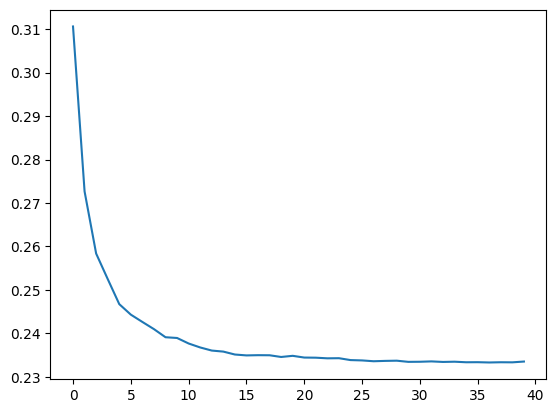

```python
import matplotlib.pyplot as plt
plt.plot([r_mse(preds[:i+1].mean(0), valid_y) for i in range(40)]);
```

## Interpreting the rmse

### How do we figure out why our validation data has worse rmse than our training data?

e.g. some reasons could be overfitting, or because the validation set covers a different time period

#### Enter: Out of Bag error calculation

In addition to checking rmse for the train & validation datasets, we can also check the rmse for what we would predict for the rows not part of our particular estimator's sample.

- Those predictions are in the `sklearn` random forest's `oob_prediction_` attribute: compare with training labels.

```python
print("train   : ", m_rmse(m, xs, y),
      "\nOutOfBag: ", r_mse(m.oob_prediction_, y),
      "\nvalid   : ", m_rmse(m, valid_xs, valid_y))
```

```
train   :  0.171299
OutOfBag:  0.211303
valid   :  0.233493
```

According to the authors, the 0.21 for the "out of bag" error is "much lower" than 0.23 the validation set error. That apparently means that in addition to normal "generalization" error (e.g. overfitting?), there's something else going on.

## Interpreting more things about the model

- How confident are we in our predictions using a particular row of data?
- For predicting with a particular row of data, what were the most important factors, and how did they influence that prediction?
- Which columns are the strongest predictors, which can we ignore?
- Which columns are effectively redundant with each other, for purposes of prediction?
- How do predictions vary, as we vary these columns?

### Prediction Values vs Prediction Confidence with Variance between Trees

The model gives us `log(saleprice)` predictions for rows of auction sale data. But what if want to know how *confident* the model was at making this prediction?

We can do this by looking at the `standard deviation` of the predictions across all the trees, instead of taking the `mean`. If they mostly agree, then we could say we're more confident; if they vary a lot, then we're less confident.

#### Btw what's in each prediction? 40 trees, each trained on a subset of rows, making a prediction for **every** row

```python
preds = np.stack([t.predict(valid_xs) for t in m.estimators_])
```

[output not shown]

[output cut: 14 more lines]

```python
preds.shape # we have 40 trees and 7988 total auctions (rows)
```

```
(40, 7988)
```

```python
preds_std = preds.std(0)
```

```python
# first five standard deviations -> standard deviation across all trees, for the first five log(saleprice) predictions
preds_std[:5]
```

```
array([0.29928914, 0.11161356, 0.12067076, 0.25767173, 0.11550318])
```

### Figuring out which features are important

Making predictions and determining confidence in the predictions is one part of the story. But it would also be good to understand what features were most important for the prediction and its confidence. Shrinking the number of columns we have to study is apparently good because a "simpler, more interpretable model is easier to roll out and maintain".

- the `sklearn` random forest has a `feature_importances_` attribute

The `feature_importances_` are calculated like this:

- The feature importance algorithm loops through each tree, and then recursively explores each branch.
- At each branch, it looks to see what feature was used for that split, and how much the model improves as a result of that split.
- The improvement (weighted by the number of rows in that group) is added to the importance score for that feature.
- This is summed across all branches of all trees, and finally the scores are normalized such that they add to 1.

```python
# we can get the feature_importances_ into a dataframe
def rf_feat_importance(m, df):
    return pd.DataFrame({'cols':df.columns,
                         'imp':m.feature_importances_}
                       ).sort_values('imp', ascending=False)
```

```python
# fi: "feature importance"
fi = rf_feat_importance(m, xs)
fi[:10]
```

|  | cols | imp |
| --- | --- | --- |
| 57 | YearMade | 0.183548 |
| 6 | ProductSize | 0.117152 |
| 30 | Coupler_System | 0.099543 |
| 31 | Grouser_Tracks | 0.073407 |
| 7 | fiProductClassDesc | 0.071620 |
| 54 | ModelID | 0.054812 |
| 65 | saleElapsed | 0.051461 |
| 3 | fiSecondaryDesc | 0.041389 |
| 12 | Enclosure | 0.036508 |
| 1 | fiModelDesc | 0.030147 |

So it looks like `YearMade`, `ProductSize`, and `Coupler_System` are the top three.

#### Plotting the Feature Importances

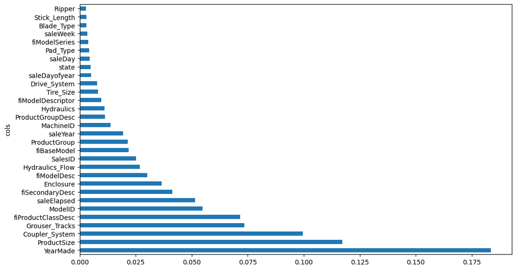

```python
def plot_fi(fi):
    return fi.plot('cols', 'imp', 'barh', figsize=(12,7), legend=False)

plot_fi(fi[:30]);
```

### Reducing the data's columns by only keeping "important" ones

We can get a less noisy understanding of the columns but understanding their contributions to the performance of the tree, and then taking out ones that seem to be much less important.

```python
# only keep columns whose feature importance, fi, is greater than .005
to_keep = fi[fi.imp>0.005].cols
len(to_keep)
```

```
21
```

#### 2. Reduce the number of columns in the dataset based on **importance**, and retrain the model with this reduced data

```python
xs_imp = xs[to_keep]
valid_xs_imp = valid_xs[to_keep]
```

```python
m = rf(xs_imp, y)
```

```python
# new rmses
#m_rmse(m, xs_imp, y), r_mse(m.oob_prediction_, y), m_rmse(m, valid_xs_imp, valid_y)

print("train   : ", m_rmse(m, xs_imp, y),
      "\nOutOfBag: ", r_mse(m.oob_prediction_, y),
      "\nvalid   : ", m_rmse(m, valid_xs_imp, valid_y))
```

```
train   :  0.181599
OutOfBag:  0.214337
valid   :  0.231258
```

#### EJ: It looks lke train & Out of Bag errors are slightly higher, but validation error is slightly lower

The point is that they're about the same; and there are fewer columns to study -- 66 vs 21:

```python
len(xs.columns), len(xs_imp.columns)
```

```
(66, 21)
```

#### Make the plot of feature importances again

Because we retrained the model with fewer columns, we don't necessarily expect the values or the order of the feature importances to remain the same.

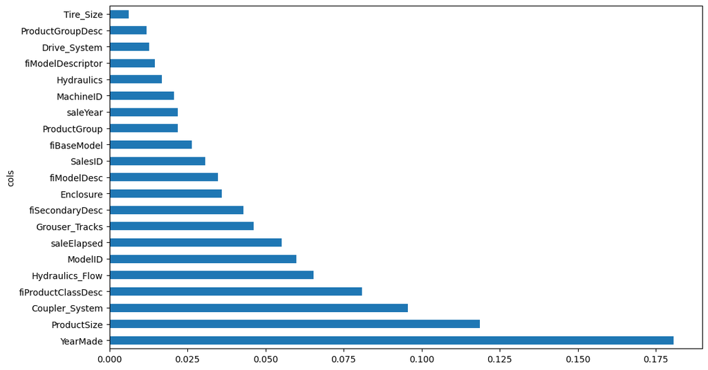

```python
plot_fi(rf_feat_importance(m, xs_imp));
```

### Reducing the data's columns by keeping the non-redundant ones

Some of the columns might be performing the same role. For instance, two columns might have values that travel together; e.g. if one column is the "short name" and the other, a longer description. In our dataset, that would be something like `ProductGroup` and `ProductGroupDesc`. We can remove one of the two columns in each pair like this.

```python
# there's a helper function in fastbook's utils for building a cluster map of the columns using spearman correlation
# i'm copying it here
# import scipy
# from scipy.cluster import hierarchy as hc
# def cluster_columns(df, figsize=(10,6), font_size=12):
#     corr = np.round(scipy.stats.spearmanr(df).correlation, 4)
#     corr_condensed = hc.distance.squareform(1-corr)
#     z = hc.linkage(corr_condensed, method='average')
#     fig = plt.figure(figsize=figsize)
#     hc.dendrogram(z, labels=df.columns, orientation='left', leaf_font_size=font_size)
#     plt.show()

# actually it turns out it's outdated - module 'scipy.cluster.hierarchy' has no attribute 'distance'
# re-written here by ChatGPT
import numpy as np
import matplotlib.pyplot as plt

from scipy.stats import spearmanr
from scipy.cluster.hierarchy import linkage, dendrogram
from scipy.spatial.distance import squareform

def cluster_columns(df, figsize=(10, 6), font_size=12, method="average"):
    # Spearman correlation between columns
    corr = spearmanr(df).correlation

    # Numerical precision can occasionally make the matrix slightly asymmetric
    corr = (corr + corr.T) / 2
    np.fill_diagonal(corr, 1)

    # Convert correlation to a distance matrix
    dist = 1 - corr

    # linkage expects the condensed distance matrix
    condensed = squareform(dist)

    # Hierarchical clustering
    Z = linkage(condensed, method=method)

    # Plot
    plt.figure(figsize=figsize)
    dendrogram(
        Z,
        labels=df.columns,
        orientation="left",
        leaf_font_size=font_size,
    )
    plt.tight_layout()
    plt.show()

    return Z
```

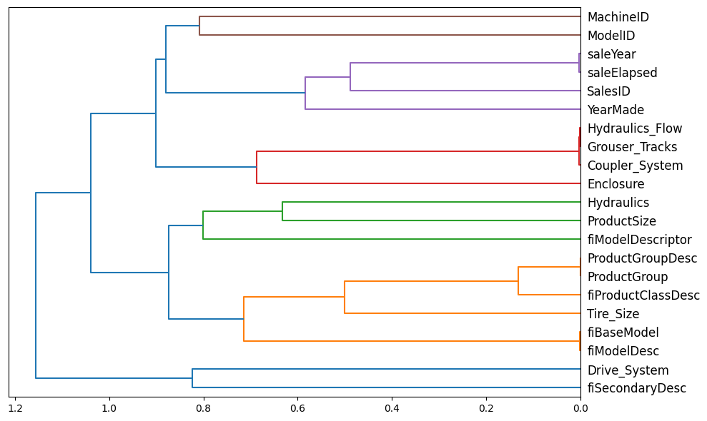

```
array([[1.30000000e+01, 1.60000000e+01, 4.67248462e-12, 2.00000000e+00],
       [9.00000000e+00, 1.20000000e+01, 3.03357261e-04, 2.00000000e+00],
       [3.00000000e+00, 1.00000000e+01, 5.12781818e-04, 2.00000000e+00],
       [2.00000000e+00, 2.30000000e+01, 1.87632712e-03, 3.00000000e+00],
       [6.00000000e+00, 1.40000000e+01, 2.21485321e-03, 2.00000000e+00],
       [4.00000000e+00, 2.10000000e+01, 1.30702784e-01, 3.00000000e+00],
       [1.10000000e+01, 2.50000000e+01, 4.88140524e-01, 3.00000000e+00],
       [1.90000000e+01, 2.60000000e+01, 5.00935571e-01, 4.00000000e+00],
       [0.00000000e+00, 2.70000000e+01, 5.83405730e-01, 4.00000000e+00],
       [1.00000000e+00, 1.70000000e+01, 6.32270562e-01, 2.00000000e+00],
       [8.00000000e+00, 2.40000000e+01, 6.86774135e-01, 4.00000000e+00],
       [2.20000000e+01, 2.80000000e+01, 7.14296064e-01, 6.00000000e+00],
       [1.80000000e+01, 3.00000000e+01, 8.00971882e-01, 3.00000000e+00],
       [5.00000000e+00, 1.50000000e+01, 8.08047270e-01, 2.00000000e+00],
       [7.00000000e+00, 2.00000000e+01, 8.23528134e-01, 2.00000000e+00],
       [3.20000000e+01, 3.30000000e+01, 8.73496728e-01, 9.00000000e+00],
       [2.90000000e+01, 3.40000000e+01, 8.79297441e-01, 6.00000000e+00],
       [3.10000000e+01, 3.70000000e+01, 9.00306831e-01, 1.00000000e+01],
       [3.60000000e+01, 3.80000000e+01, 1.03857113e+00, 1.90000000e+01],
       [3.50000000e+01, 3.90000000e+01, 1.15655651e+00, 2.10000000e+01]])
```

```python
# we can cluster the smaller set of columns that we already reduced by looking at importance
cluster_columns(xs_imp)
```

You can see:

- `SaleYear` and `SaleElapsed` are similar;
- `ProductGroup` and `ProductGroupDesc`;
- `fiBaseModel` and `fiModelDesc`

#### A strategy for checking which columns are redundant: use the OOB score

Basically just write a loop where you take out the column and check what your accuracy is! You want to be able to remove these columns without impacting the accuracy.

Write a function that quickly trains a random forest and returns the OOB score:

- quickly: use a lower `max_samples` and higher `min_samples_leaf`
- `oob_score_`: an `sklearn` trained random forest attribute that ranges between 1.0 for a perfect model and 0.0 for a random model.

(note: before we were looking at `oob_prediction_` numbers to calculate the rmse)

```python
def get_oob(df):
    m = RandomForestRegressor(n_estimators=40, min_samples_leaf=15,
        max_samples=50000, max_features=0.5, n_jobs=-1, oob_score=True)
    m.fit(df, y)
    return m.oob_score_
```

**Check the oob_score_ for the model before dropping out any of the potential redundancies**

```python
get_oob(xs_imp)
```

```
0.8781871105555898
```

**Check what the oob_score_ would be for each model that leaves out one potential redundancy at a time**

```python
{c:get_oob(xs_imp.drop(c, axis=1)) for c in (
    'saleYear', 'saleElapsed', 'ProductGroupDesc','ProductGroup',
    'fiModelDesc', 'fiBaseModel',
    'Hydraulics_Flow','Grouser_Tracks', 'Coupler_System')}
```

```
{'saleYear': 0.8766551991821786,
 'saleElapsed': 0.8728956088478752,
 'ProductGroupDesc': 0.8776062671534415,
 'ProductGroup': 0.8778658840110456,
 'fiModelDesc': 0.8760580964700083,
 'fiBaseModel': 0.8761182434840864,
 'Hydraulics_Flow': 0.8777899505517228,
 'Grouser_Tracks': 0.8775854930886188,
 'Coupler_System': 0.8771767764627115}
```

The authors don't say but I think we're supposed to see these numbers as about the same as the original `oob_score_`, because then they move on to see what happens if we drop one of each pair.

```python
to_drop = ['saleYear', 'ProductGroupDesc', 'fiBaseModel', 'Grouser_Tracks']
get_oob(xs_imp.drop(to_drop, axis=1))
```

```
0.8738890620563834
```

This, too, is in the ballpark of the original `oob_score_`, so the authors suggest we go for it.

#### The final set of non-redundant columns - drop in both the train & valid sets

```python
xs_final = xs_imp.drop(to_drop, axis=1)
valid_xs_final = valid_xs_imp.drop(to_drop, axis=1)
```

#### And save the data to pickles, apparently

```python
save_pickle(path/'xs_final.pkl', xs_final)
save_pickle(path/'valid_xs_final.pkl', valid_xs_final)
```

#### If we wanted to start from our reduced-column dataset here, we can load the train and valid data pickles

```python
xs_final = load_pickle(path/'xs_final.pkl')
valid_xs_final = load_pickle(path/'valid_xs_final.pkl')
```

#### 3. Let's check out how the model performs on the reduced data

Seems to do basically the same.

```python
m = rf(xs_final, y)
m_rmse(m, xs_final, y), m_rmse(m, valid_xs_final, valid_y)
```

```
(0.183506, 0.232802)
```

### Using partial dependence plots to learn how the most important columns impact all the predictions

We saw that the two columns that are the most important are the:

- YearMade
- ProductSize

Well, after we re-ran, the Coupler_System squeezed into second place, but ok. After I cleared everything and ran again the YearMade and ProductSize were once again in the top 2. Not sure what changed, I guess the random forests were different random groups.

**Partial Dependence Plot**: "if a row varied on nothing other than the feature in question, how would it impact the dependent variable?" E.g. "how does `YearMade` impact sale price, all other things being equal?"

For each unique YearMade in the valid dataset (1950 to 2011):

- make a copy of the valid dataset but replace all YearMade with 1950. Predict SalePrice for each row of this dataset. Take the average over all the rows of the SalePrice.
- make a copy of the valid dataset but replace all YearMade with 1951. Predict SalePrice for each row of this dataset. Take the average over all the rows of the SalePrice.
- ...
- make a copy of the valid dataset but replace all YearMade with 2011. Predict SalePrice for each row of this dataset. Take the average over all the rows of the SalePrice.

Then, make a the **Partial Dependence Plot** plot.

- The x-axis is the YearMade
- the y-axis is the average predicted SalePrice

**BTW** we have been using the "final" set of columns in both the train and valid xs.

#### Check the count of values per category for ProductSize

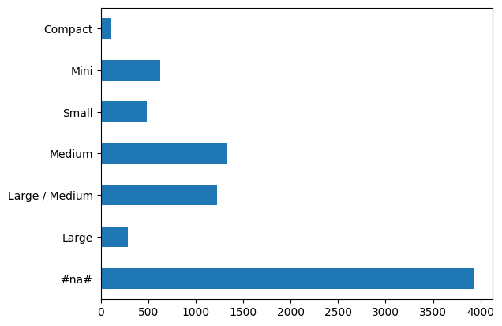

```python
# these lines were plotting but mis-labeling the bars
#p = valid_xs_final['ProductSize'].value_counts(sort=False).plot.barh()
#c = to.classes['ProductSize']
#plt.yticks(range(len(c)), c);

# ChatGPT fixing the code so the labels come out right
# but the bars still don't 100% match the fastbook bars... not sure who's wrong
classes = list(to.classes['ProductSize'])

counts = (
    valid_xs_final['ProductSize']
    .value_counts()
    .reindex(range(len(classes)), fill_value=0)
)

counts.index = classes
counts.plot.barh()
```

#### Do the same thing for the YearMade column, but it's continuous so make a histagram

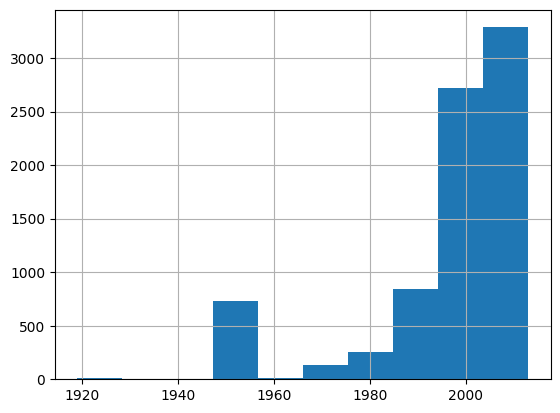

```python
ax = valid_xs_final['YearMade'].hist()
```

Main thing to notice: "Other than the special value 1950 which we used for coding missing year values, most of the data is from after 1990."

#### Make the Partial Dependence plot for YearMade

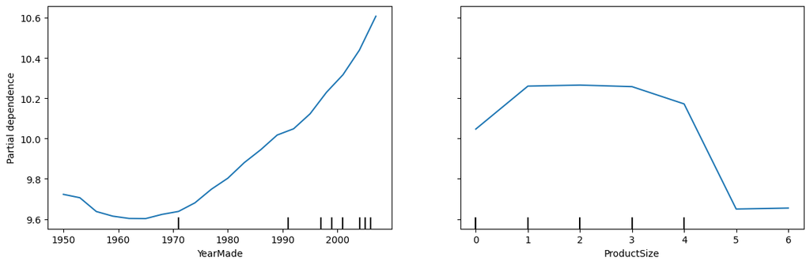

```python
from sklearn.inspection import PartialDependenceDisplay

fig, ax = plt.subplots(figsize=(12, 4))
PartialDependenceDisplay.from_estimator(
  m,
  valid_xs_final.astype(float), # needed to add the .astype(float) or it wasn't working/doing weird things
  ['YearMade', 'ProductSize'],
  grid_resolution=20,
  ax=ax,
)
plt.tight_layout()
plt.show()
```

### Gauging Data Leakage

Data leakage is basically when information from the test set, which you *should not* be able to use to train the data, leaks into the training set. Things to look out for:

- improbably high accuracies
- strange predictors (see: "Figuring out which features are important" earlier in this notebook)
- partial dependence plots (see: "Using partial dependence plots to learn how the most important columns impact all the predictions" just above, in this notebook)
- tree interpreters (see: "How the important factors actually contribute to specific predictions", just following, in this notebook)

E.g. let's say sales always take place during weekdays, but if a sale price is above a threshhold, the database registers that the sale took place on a Sunday because of some kind of batch process that runs over the weekend. The model might learn that high prices only occur on Sundays. If the company is trying to use the model during the week to predict their auction sale prices, it probably wouldn't predict any sale prices above the threshold because none of the rows would have Sunday.

#### How the important factors actually contribute to specific predictions

- For the partial dependences, we checked the impact on the predicted average saleprice from setting every row in a dataset to a particular YearMade, for each YearMade from the dataset.
- With tree interpreters, we're going to follow the path of just one row through the decision tree to predict one saleprice.

How? "Let's say we are looking at some particular item at auction. Our model might predict that this item will be very expensive, and we want to know why."

- So, we take that one row of data and put it through the first decision tree, looking to see what split is used at each point throughout the tree.
- For each split, we see what the increase or decrease in the addition is, compared to the parent node of the tree.
- We do this for every tree, and add up the total change in importance by split variable.

```python
#from waterfall_chart import plot as waterfall
```

#### NOTE: the treeinterpreter library hasn't been updated since 2021 and doesn't seem to be compatible with sklearn 1.9

So I'm abandoning this approach in favor of something called "SHAP" recommended by Claude

#### Original:

```
from treeinterpreter import treeinterpreter
prediction,bias,contributions = treeinterpreter.predict(m, row.values)
```

treeinterpreter:

- **prediction** = the model's predicted value for that row
- **bias** = the average prediction across all training data (baseline) "based on taking the mean of the dependent variable (i.e., the model that is the root of every tree)"
- **contributions** = how much each feature pushed the prediction up or down from the bias, "the most interesting bit— it tells us the total change in prediction due to each of the independent variables."

The relationship is exact: bias + sum(contributions) = prediction

#### With SHAP:

```
import shap
explainer = shap.TreeExplainer(m)
shap_values = explainer.shap_values(row)
```

SHAP:

- **prediction** = explainer.expected_value + sum(shap_values[0])
- **bias** = explainer.expected_value
- **contributions** = shap_values

```python
# first 5 rows of validation set
row = valid_xs_final.iloc[:5]
```

```python
# the tree interpreter approach

# from treeinterpreter import treeinterpreter
# prediction,bias,contributions = treeinterpreter.predict(m, row.values)

# treeinterpreter: Looking at the first row

# prediction[0], bias[0], contributions[0].sum()
# (array([10.01216396]), 10.104746057831765, -0.0925820990266335)
```

```python
# using shap instead tree interpretation
#!pip install --upgrade shap
import shap
explainer = shap.TreeExplainer(m)
shap_values = explainer.shap_values(row)

# shap: Looking at the first row
# prediction[0] = explainer.expected_value + shap_values[0].sum()
# bias[0] = explainer.expected_value
# contributions[0].sum() = shap_values[0].sum()

# prediction[0], bias[0], contributions[0].sum()
explainer.expected_value + shap_values[0].sum(), explainer.expected_value, shap_values[0].sum()
# (array([9.94610828]), array([10.10412849]), np.float64(-0.15802020657617752))
```

```
(array([9.94610828]), array([10.10412849]), np.float64(-0.15802020657617752))
```

#### The TreeInterpreter vs Shap are not exactly equivalent; they use slightly different algorithms

...and thus produce slightly different values

Claude's interpretation of their differences: "The bias values are very close (~10.104) which makes sense — both compute the average prediction over the training data, so they should nearly match. Small difference is likely just a different model (different random seed between runs).

The prediction and contributions differ more noticeably (-0.09 vs -0.16), which is expected — SHAP and treeinterpreter use genuinely different algorithms to allocate credit among features. treeinterpreter follows the exact decision path; SHAP computes Shapley values which average over all possible feature orderings. **Same direction (both negative, both predicting below baseline), different magnitude.**

**The conceptual interpretation is the same**:

- this bulldozer is predicted to sell for less than the average, and
- SHAP is telling you which features are responsible for pulling it down

We can see which features are pulling in which direction with the **waterfall plot**.

#### Waterfall Plot to check what each feature does to the final predicted saleprice, "useful in production"

```python
#valid_xs_final.columns
```

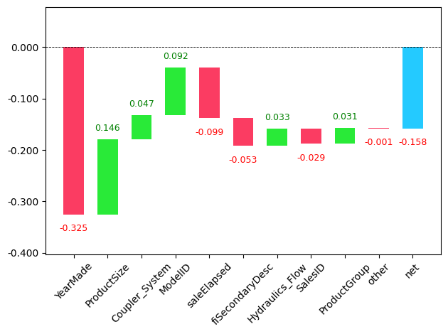

```python
# had to swap out contributions[0] for shap_values[0] (these are the same thing)
from waterfall_chart import plot as waterfall
waterfall(valid_xs_final.columns, shap_values[0], threshold=0.08,
          rotation_value=45,formatting='{:,.3f}');
```

I think the way to interpret this is:

- YearMade drags the price down
- Product Size brings it up
- Coupler_System brings it up
- Model ID brings it up
- saleElapsed brings it down
- fiSecondaryDesc brings it down
- Hydraulics Flow brings it up
- Sales ID brings it down
- ProductGroup brings it up
- other brings it slightly down
- for a slightly less than the average sale price for all auctioned machines?

EJ: My questions would be:

- Why would SaleID be relevant? (maybe this is basically just a proxy for year...? Larger numbers for later sales?
- Same question for saleElapsed? (it's also greater for later sales... so probably also a proxy for year?)

## Generalizing Random Forests for New Data

### Problems with Random Forests for New Data

#### a. Timeseries with random forests are problematic

- "Remember, a random forest just averages the predictions of a number of trees.
- And a tree simply predicts the average value of the rows in a leaf.
- Therefore, a tree and a random forest can never predict values outside of the range of the training data.

This is particularly problematic for data where there is a trend over time, such as inflation, and you wish to make predictions for a future time. Your predictions will be systematically too low.

#### b. Column values not present in the training set ("out of domain") will never be predicted

### Solving the Problems with Random Forests for New Data

#### Option 1: Check whether the distribution of data is different between train and valid/test and remove bad columns

You can actually use a Random Forest to check whether the distributions of data in your test set match your training set! And, if it's different, you can **find out which columns reflect the difference**.

Use the random forest to: **predict whether a row is in the validation set or the training set**.

How?

1. Combine our training and validation sets together
2. create a dependent variable that represents which dataset each row comes from
3. build a random forest using that data
4. and get its feature importance

#### Feature Importance for train/valid prediction

```python
df_dom = pd.concat([xs_final, valid_xs_final])
is_valid = np.array([0]*len(xs_final) + [1]*len(valid_xs_final))

m = rf(df_dom, is_valid)
rf_feat_importance(m, df_dom)[:6]
```

|  | cols | imp |
| --- | --- | --- |
| 5 | saleElapsed | 0.891161 |
| 10 | SalesID | 0.069815 |
| 12 | MachineID | 0.033834 |
| 0 | YearMade | 0.001726 |
| 4 | ModelID | 0.000681 |
| 15 | Tire_Size | 0.000516 |

Result: "three columns that differ significantly between the training and validation sets: `saleElapsed`, `SalesID`, and `MachineID`"

- saleElapsed: basically encodes the sale date - the train and valid sets were "earlier" and "later"
- sales id: probably ticks up over time as more sales are made
- machine id: maybe it also ticks up over time in these auctions

#### RMSE for final model after removing each problematic columns one at a time

```python
m = rf(xs_final, y)
print('orig', m_rmse(m, valid_xs_final, valid_y))

for c in ('SalesID','saleElapsed','MachineID'):
    m = rf(xs_final.drop(c,axis=1), y)
    print(c, m_rmse(m, valid_xs_final.drop(c,axis=1), valid_y))
```

```
orig 0.233494
SalesID 0.229908
saleElapsed 0.236235
MachineID 0.230896
```

Based on these accuracies (which look mostly similar to the original -- accuracy looks .003 worse for `saleElapsed`), "it looks like we should be able to remove `SalesID` and `MachineID` without losing any accuracy."

```python
time_vars = ['SalesID','MachineID']
xs_final_time = xs_final.drop(time_vars, axis=1)
valid_xs_time = valid_xs_final.drop(time_vars, axis=1)

m = rf(xs_final_time, y)
m_rmse(m, valid_xs_time, valid_y)
```

```
0.229757
```

#### Takeaway: Check for domain shifts. Make a random forest trained on the train/valid dataset (make an is_valid column) and use the feature importance function to figure out columns to try removing from the model to improve generalization ability

-> "Slightly improved the model's accuracy; but more importantly, it should make it more resilient over time, and easier to maintain and understand. We recommend that for all datasets you try building a model where your dependent variable is `is_valid`, like we did here."

#### Option 2: Try removing old data

"old data shows relationships that just aren't valid any more"

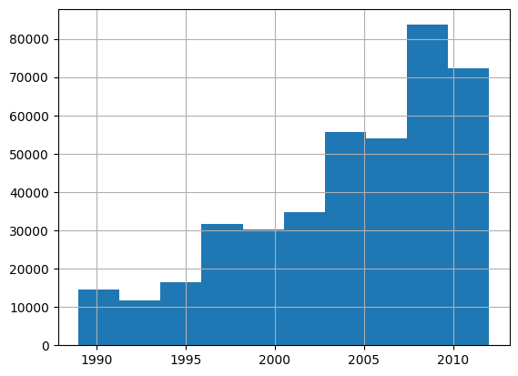

```python
xs['saleYear'].hist();
```

Try training on just this subset:

```python
filt = xs['saleYear']>2004
xs_filt = xs_final_time[filt]
y_filt = y[filt]
```

```python
m = rf(xs_filt, y_filt)
m_rmse(m, xs_filt, y_filt), m_rmse(m, valid_xs_time, valid_y)
```

```
(0.177621, 0.229264)
```

The authors look at these numbers and call them "a tiny bit better": "It's a tiny bit better, which shows that you shouldn't always just use your entire dataset; sometimes a subset can be better."

### Option 3: Use a Neural Net

```python
df_nn = pd.read_csv(path/'TrainAndValid.csv', low_memory=False)
df_nn['ProductSize'] = df_nn['ProductSize'].astype('category')
df_nn['ProductSize'] = df_nn['ProductSize'].cat.set_categories(sizes, ordered=True)
df_nn[dep_var] = np.log(df_nn[dep_var])
df_nn['saledate'] = pd.to_datetime(df_nn['saledate'])
df_nn = add_datepart(df_nn, 'saledate')
```

```python
# just use the columns that we've been working with after all the cleanup before
df_nn_final = df_nn[list(xs_final_time.columns) + [dep_var]]
```

For the neural net, we need to create embeddings for the categorical columns

- To create embeddings, fastai needs to determine which columns should be treated as categorical variables.
- It does this by comparing the number of distinct levels in the variable to the value of the max_card parameter.
- If it's lower, fastai will treat the variable as categorical.

Embedding sizes larger than 10,000 should generally only be used after you've tested whether there are better ways to group the variable, so we'll use 9,000 as our max_card

```python
cont_nn,cat_nn = cont_cat_split(df_nn_final, max_card=9000, dep_var=dep_var)
# EJ: just noting that we did use this function earlier: cont,cat = cont_cat_split(df_train_and_valid, 1, dep_var=dep_var)
#     the 1: "The 1 is just a conservative threshold saying "don't try to treat numeric columns with few unique values as categorical."
```

**Apparently we're doing this to check that saleElapsed is treated as continuous:** "there's one variable that we absolutely do not want to treat as categorical: the saleElapsed variable. A categorical variable cannot, by definition, extrapolate outside the range of values that it has seen, but we want to be able to predict auction sale prices in the future. Let's verify that cont_cat_split did the correct thing."

```python
cont_nn
```

```
['saleElapsed']
```

**For the categorical columns, how many categories do we have for each?**

```python
df_nn_final[cat_nn].nunique()
```

```
YearMade                73
ProductSize              6
Coupler_System           2
fiProductClassDesc      74
ModelID               5281
fiSecondaryDesc        177
Enclosure                6
fiModelDesc           5059
Hydraulics_Flow          3
ProductGroup             6
Hydraulics              12
fiModelDescriptor      140
Tire_Size               17
Drive_System             4
dtype: int64
```

#### The size of ModelID and fiModelDesc is sort of high (~5000 unique values where the next highest is in the hundreds) and that's annoying because we'd need a large embedding vector

... So we'll try to see if the model accuracy remains the same if we just got rid of them!

```python
# recall our recent accuracies
m_rmse(m, xs_filt, y_filt), m_rmse(m, valid_xs_time, valid_y)
```

```
(0.177621, 0.229264)
```

```python
# remove from train & validation inputs
xs_filt2 = xs_filt.drop('ModelID', axis=1)
valid_xs_time2 = valid_xs_time.drop('ModelID', axis=1)
# recreate the random forest on the new xs_filt2
m2 = rf(xs_filt2, y_filt)
# check the m_rmse for this model on the train and valid data (without the column we dropped)
m_rmse(m2, xs_filt2, y_filt), m_rmse(m2, valid_xs_time2, valid_y)
```

```
(0.17895, 0.232571)
```

```python
# remove from train & validation inputs
xs_filt2 = xs_filt.drop('fiModelDesc', axis=1)
valid_xs_time2 = valid_xs_time.drop('fiModelDesc', axis=1)
# recreate the random forest on the new xs_filt2
m2 = rf(xs_filt2, y_filt)
# check the m_rmse for this model on the train and valid data (without the column we dropped)
m_rmse(m2, xs_filt2, y_filt), m_rmse(m2, valid_xs_time2, valid_y)
```

```
(0.180477, 0.232569)
```

```python
# remove from train & validation inputs
xs_filt2 = xs_filt.drop('fiModelDescriptor', axis=1)
valid_xs_time2 = valid_xs_time.drop('fiModelDescriptor', axis=1)
# recreate the random forest on the new xs_filt2
m2 = rf(xs_filt2, y_filt)
# check the m_rmse for this model on the train and valid data (without the column we dropped)
m_rmse(m2, xs_filt2, y_filt), m_rmse(m2, valid_xs_time2, valid_y)
```

```
(0.176707, 0.229083)
```

#### We can't actually remove `ModelID` and `fiModelDesc` because the accuracy worsens, but we can remove another seemingly redundant field, `fiModelDescriptor`

```python
cat_nn.remove('fiModelDescriptor')
```

#### Create the TabularPandas object like before, but now with Normalization

"We can create our TabularPandas object in the same way as when we created our random forest, with one very important addition: normalization. A random forest does not need any normalization—the tree building procedure cares only about the order of values in a variable, not at all about how they are scaled. But as we have seen, a neural network definitely does care about this. Therefore, we add the Normalize processor when we build our TabularPandas object"

```python
from fastai.tabular.all import TabularPandas, Categorify, FillMissing, Normalize
```

```python
procs_nn = [Categorify, FillMissing, Normalize]
to_nn = TabularPandas(df_nn_final, procs_nn, cat_nn, cont_nn,
                      splits=splits, y_names=dep_var)
```

"Tabular models and data don't generally require much GPU RAM, so we can use larger batch sizes"

```python
dls = to_nn.dataloaders(1024)
```

#### We're making a regression model, best practices to set y_range

"so let's find the min and max of our dependent variable"

```python
y = to_nn.train.y
y.min(),y.max()
```

```
(np.float32(8.465899), np.float32(11.863583))
```

#### Create the Learner

"By default, for tabular data fastai creates a neural network with two hidden layers, with 200 and 100 activations, respectively. This works quite well for small datasets, but here we've got quite a large dataset, so we increase the layer sizes to 500 and 250"

```python
from fastai.tabular.all import tabular_learner, F
learn = tabular_learner(dls, y_range=(8,12), layers=[500,250],
                        n_out=1, loss_func=F.mse_loss)
```

**Use the learning rate finder**

```
SuggestedLRs(valley=0.0003311311302240938)
```

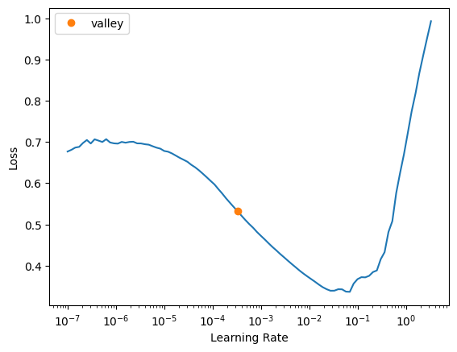

```python
learn.lr_find()
```

#### Train the learner

We're not fine tuning, so "train with fit_one_cycle for a few epochs and see how it looks"

```python
learn.fit_one_cycle(5, 1e-2)
```

| epoch | train_loss | valid_loss | time |
| --- | --- | --- | --- |
| 0 | 0.063897 | 0.068394 | 00:04 |
| 1 | 0.052258 | 0.055638 | 00:03 |
| 2 | 0.047633 | 0.056667 | 00:03 |
| 3 | 0.042598 | 0.051853 | 00:03 |
| 4 | 0.039863 | 0.050154 | 00:03 |

```python
preds,targs = learn.get_preds()
r_mse(preds,targs)
```

```
0.22395
```

**Apparently .223 is 'quite a bit better' than the random forest (...at .229...)** "although it took longer to train, and it's fussier about hyperparameter tuning"

```python
learn.save('nn')
```

```
Path('models/nn.pth')
```

### Fastai's Tabular learner and Tabular model

- Tabular learner: https://docs.fast.ai/tabular.learner.html - regular learner with customized `predict` method
  1. `get_emb_sz` to calculate appropriate embedding sizes
  2. create a Tabular model
- Tabular model: https://docs.fast.ai/tabular.model.html
  - takes columns of continuous (continuous variables are concatenated as well) or categorical data (Categorical independent variables are passed through an embedding and concatenated)
  - predicts a category (a classification model) or a continuous value (a regression model)

## Ensembling

### Bagging different kinds of models

**Bagging:** Just like how we can ensemble a bunch of decision trees together into a random forest by averaging the predictions, we can ensemble the random forest with the neural network.

PyTorch model and our sklearn model create data of different types:

- PyTorch gives us a rank-2 tensor (i.e, a column matrix), whereas
- NumPy gives us a rank-1 array (a vector).

Easily fixable: "squeeze removes any unit axes from a tensor, and to_np converts it into a NumPy array"

```python
from fastai.torch_core import to_np
rf_preds = m.predict(valid_xs_time)
ens_preds = (to_np(preds.squeeze()) + rf_preds) /2
```

```python
r_mse(ens_preds,valid_y)
```

```
0.221364
```

^ better than either by itself (.... EJ: again, by just a little bit...)

### Boosting

**Boosting**: instead of averaging the predictions, add them

Procedure:

- Train a small model that underfits your dataset.
- Calculate the predictions in the training set for this model.
- Subtract the predictions from the targets; these are called the "residuals" and represent the error for each point in the training set.
- Go back to step 1, but instead of using the original targets, use the residuals as the targets for the training.
- Continue doing this until you reach some stopping criterion, such as a maximum number of trees, or you observe your validation set error getting worse.

Effect:

- Each new tree will be attempting to fit the error of all of the previous trees combined.
- Because we are continually creating new residuals, by subtracting the predictions of each new tree from the residuals from the previous tree, the residuals will get smaller and smaller.

Predictions with an ensemble of boosted trees:

- calculate the predictions from each tree, and then
- add them all together

**Boosting Strategies**

- Gradient boosting machines (GBMs) and
- gradient boosted decision trees (GBDTs)

Library that implements this circa 2022: `XGBoost`

**Boosting Downfalls: overfitting**

"Using more trees in a random forest does not lead to overfitting, because each tree is independent of the others. But in a boosted ensemble, the more trees you have, the better the training error becomes, and eventually you will see overfitting on the validation set."

**Gradient boosting** was in rapid development when fastbook was being published, so the authors didn't want to spend too much time showing how to "train a gradient boosted tree ensemble".

"As we write this, sklearn has just added a `HistGradientBoostingRegressor` class that provides excellent performance. There are many hyperparameters to tweak for this class, and for all gradient boosted tree methods we have seen. Unlike random forests, gradient boosted trees are extremely sensitive to the choices of these hyperparameters; in practice, most people use a loop that tries a range of different hyperparameters to find the ones that work best."

#### Gradient Boosting: 2026 (according to ChatGPT)

Instead of one implementation, there are now three dominant gradient boosting libraries.

| Library | Strengths | Typical use |
| --- | --- | --- |
| XGBoost | Extremely robust, mature, excellent defaults | General-purpose baseline |
| LightGBM | Very fast on large datasets, low memory usage | Large tabular datasets |
| CatBoost | Handles categorical variables exceptionally well with minimal preprocessing | Mixed numerical/categorical datasets |

Hyperparameters for Gradient Boosting:

- learning_rate
- max_leaf_nodes (or max_depth)
- min_samples_leaf
- max_bins
- l2_regularization
- max_features
- n_estimators

Methods for searching parameter space:

- Optuna
- Bayesian optimization
- RandomizedSearchCV
- HalvingGridSearchCV
- AutoML systems

**special note**: "One thing many people expected in 2020 was that tabular neural networks would replace boosting. That largely didn't happen. Deep learning has become dominant for images, language, audio, and many multimodal tasks, but for ordinary structured tables, gradient-boosted trees remain extremely competitive. Recent competition analyses still show XGBoost, LightGBM, and CatBoost as the most common winning approaches, though AutoML systems and newer tabular foundation models are starting to appear in some competitions."

### Embeddings + small decision tree might be a speedy replacement for inference time predictions

"you can get much of the performance improvement of a neural network without actually having to use a neural network at inference time. You could just use an embedding, which is literally just an array lookup, along with a small decision tree ensemble.

These embeddings need not even be necessarily learned separately for each model or task in an organization. Instead, once a set of embeddings are learned for some column for some task, they could be stored in a central place, and reused across multiple models. In fact, we know from private communication with other practitioners at large companies that this is already happening in many places."

## Takeaways from this lesson on three methods for tabular data

- Random forests are the easiest to train, because they are extremely resilient to hyperparameter choices and require very little preprocessing. They are very fast to train, and should not overfit if you have enough trees. But they can be a little less accurate, especially if extrapolation is required, such as predicting future time periods.
- Gradient boosting machines in theory are just as fast to train as random forests, but in practice you will have to try lots of different hyperparameters. They can overfit, but they are often a little more accurate than random forests.
- Neural networks take the longest time to train, and require extra preprocessing, such as normalization; this normalization needs to be used at inference time as well. They can provide great results and extrapolate well, but only if you are careful with your hyperparameters and take care to avoid overfitting.

### How to choose a strategy for tabular data

1. "We suggest starting your analysis with a random forest. This will give you a strong baseline, and you can be confident that it's a reasonable starting point. You can then use that model for feature selection and partial dependence analysis, to get a better understanding of your data."
2. "From that foundation, you can try neural nets and GBMs, and if they give you significantly better results on your validation set in a reasonable amount of time, you can use them. If decision tree ensembles are working well for you, try adding the embeddings for the categorical variables to the data, and see if that helps your decision trees learn better."